# Pratikum MPDW 2

```r
library(dplyr)
library(TTR)
library(forecast)
library(lmtest) #digunakan untuk uji formal pendeteksian autokorelasi
library(orcutt) #untuk membuat model regresi Cochrane-Orcutt
  #untuk membuat model regresi Hildreth-Lu
```

# Input Data

```r
library(readxl)
data1 <- read_excel("C:\\Users\\aisya\\Documents\\MATKUL\\Semester 5\\MPDW\\data_regresi_deret_waktu.xlsx")
data2 <- read_excel("C:\\Users\\aisya\\Documents\\MATKUL\\Semester 5\\MPDW\\Sales_Advertising_Data.xlsx")

# menampilkan 5 data pertama
head(data1)
```

```
## # A tibble: 6 × 3
##   Period Market_share Price
##    <dbl>        <dbl> <dbl>
## 1      1         3.63  0.97
## 2      2         4.2   0.95
## 3      3         3.33  0.99
## 4      4         4.54  0.91
## 5      5         2.89  0.98
## 6      6         4.87  0.9
```

```r
head(data2)
```

```
## # A tibble: 6 × 3
##    Year Sales Advertising
##   <dbl> <dbl>       <dbl>
## 1  1975  11.7         9.4
## 2  1976  12           9.6
## 3  1977  12.3        10
## 4  1978  12.8        10.4
## 5  1979  13.1        10.8
## 6  1980  13.6        10.9
```

# Analisis Data 1

## Eksplorasi Data 1

### Scatter Plot

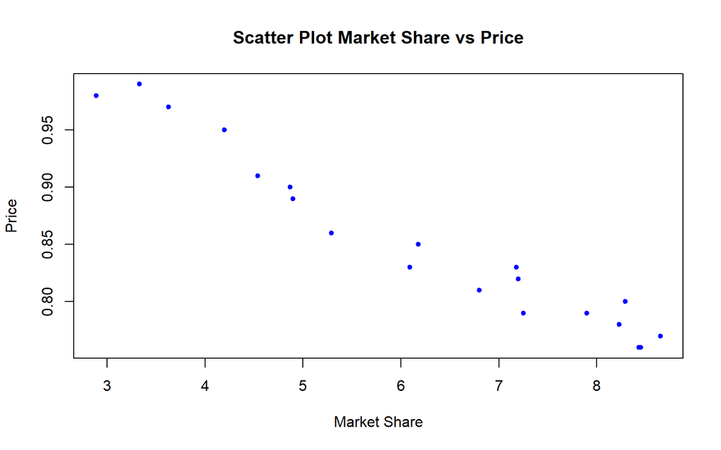

```r
#Eksplorasi Data
#Pembuatan Scatter Plot
plot(data1$Market_share, data1$Price, pch = 20, col = "blue",
     main = "Scatter Plot Market Share vs Price",
     xlab = "Market Share",
     ylab = "Price")
```

```r
#Menampilkan Nilai Korelasi
cor(data1$Market_share, data1$Price)
```

```
## [1] -0.9752564
```

### Boxplot Market Share

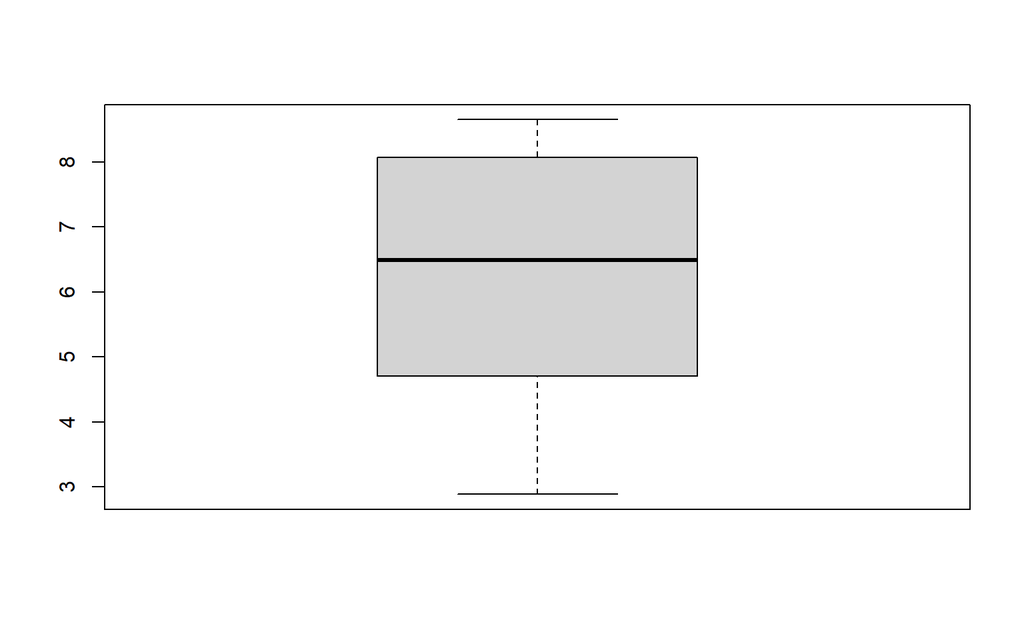

```r
boxplot(data1$Market_share)
```

### Boxplot Price

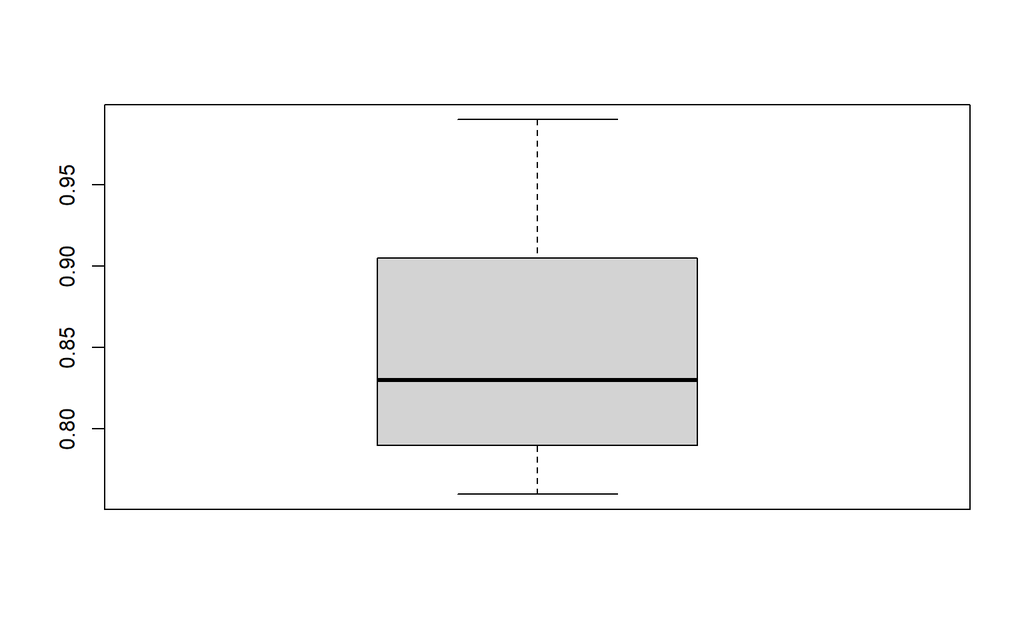

```r
boxplot(data1$Price)
```

## Pemodelan Regresi Linear

```r
model1 <- lm(Market_share~Price, data1)
summary(model1)
```

```
##
## Call:
## lm(formula = Market_share ~ Price, data = data1)
##
## Residuals:
##      Min       1Q   Median       3Q      Max
## -0.73068 -0.29764 -0.00966  0.30224  0.81193
##
## Coefficients:
##             Estimate Std. Error t value Pr(>|t|)
## (Intercept)   26.910      1.110   24.25 3.39e-15 ***
## Price        -24.290      1.298  -18.72 3.02e-13 ***
## ---
## Signif. codes:  0 '***' 0.001 '**' 0.01 '*' 0.05 '.' 0.1 ' ' 1
##
## Residual standard error: 0.4287 on 18 degrees of freedom
## Multiple R-squared:  0.9511, Adjusted R-squared:  0.9484
## F-statistic: 350.3 on 1 and 18 DF,  p-value: 3.019e-13
```

Model regresi yang diperoleh adalah
$$\hat{Y}=26.910-24.290X$$
dengan nilai p-value untuk Price < 0.05, sehingga dapat disimpulkan bahwa Price berpengaruh signifikan terhadap Market Share pada taraf nyata 5%. Nilai Adjusted R-squared sebesar 0.9484 menunjukkan bahwa setelah disesuaikan dengan jumlah variabel dalam model, sekitar 94.84% variasi Market Share dapat dijelaskan oleh Price. Selain itu, hasil uji F menghasilkan p-value < 0.05, sehingga model regresi secara keseluruhan signifikan, yang berarti model dengan Price sebagai prediktor mampu menjelaskan variasi Market Share secara signifikan.

## Pemenuhan Asumsi

### Linearitas

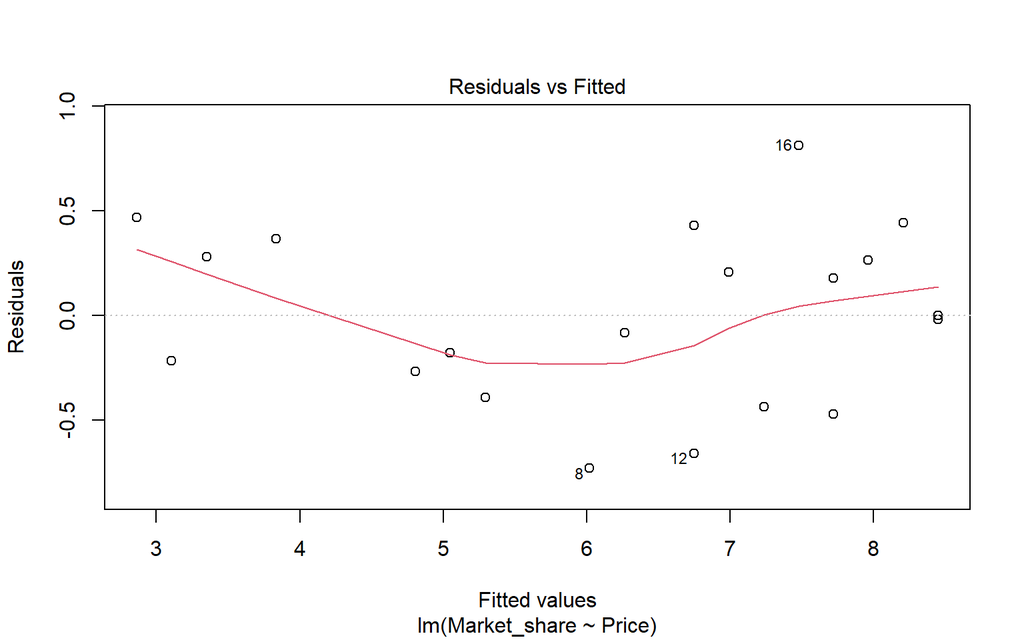

```r
plot(model1, which = 1)
```

### Normalitas

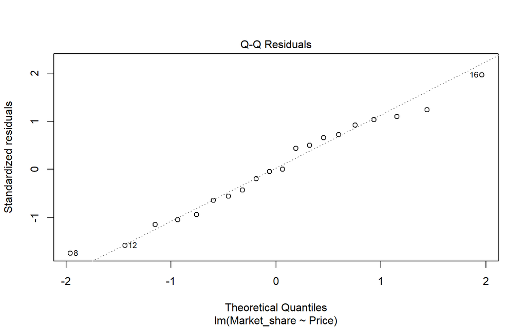

```r
plot(model1, which = 2)
```

```r
shapiro.test(residuals(model1))
```

```
##
##  Shapiro-Wilk normality test
##
## data:  residuals(model1)
## W = 0.9744, p-value = 0.8437
```

Uji Shapiro-Wilk menghasilkan nilai p-value sebesar 0.8437 > alpha 0.05. Oleh karena itu, tidak cukup bukti untuk menolak H0, sehingga dapat disimpulkan bahwa sisaan berdistribusi normal pada taraf nyata 5%.

### Homogenitas

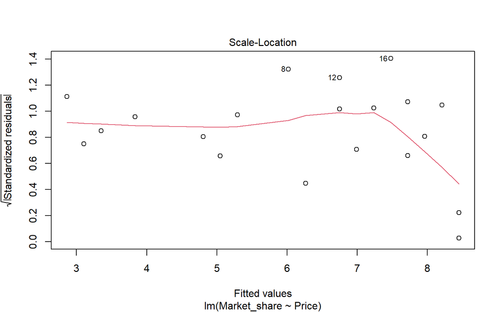

```r
plot(model1, which = 3)
```

```r
bptest(model1)
```

```
##
##  studentized Breusch-Pagan test
##
## data:  model1
## BP = 0.11646, df = 1, p-value = 0.7329
```

Uji Breusch-Pagan menghasilkan nilai p-value sebesar 0.7329 > alpha 0.05. Oleh karena itu, tidak cukup bukti untuk menolak H0, sehingga dapat disimpulkan bahwa ragam sisaan homogen pada taraf nyata 5%.

### Sisaan Saling Bebas

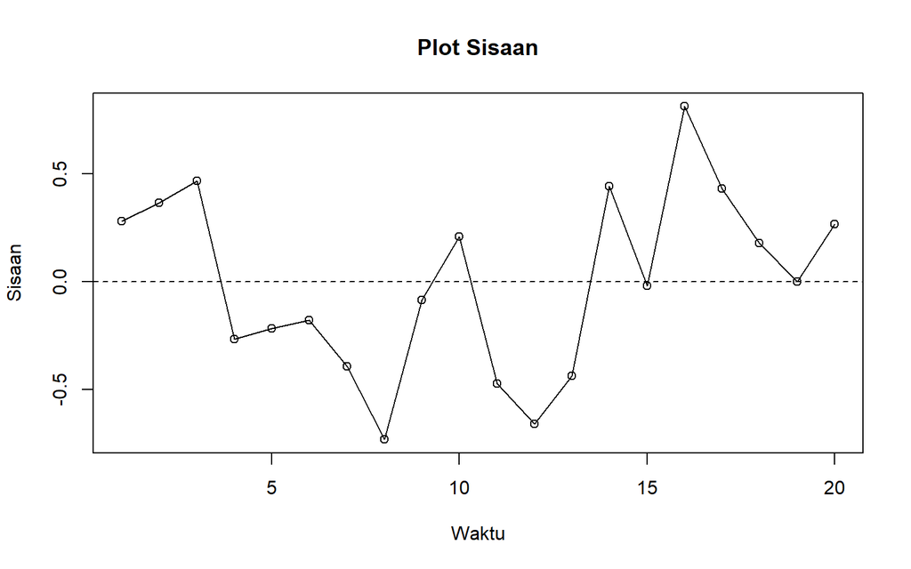

```r
plot(residuals(model1),
     type = "o",
     xlab = "Waktu",
     ylab = "Sisaan",
     main = "Plot Sisaan")
abline(h = 0, lty = 2)
```

```r
dwtest(model1)
```

```
##
##  Durbin-Watson test
##
## data:  model1
## DW = 1.1358, p-value = 0.009813
## alternative hypothesis: true autocorrelation is greater than 0
```

Berdasarkan hasil DW Test, didapatkan nilai $DW = 1.1358$ dan *p-value* = $0.009813$. Berdasarkan tabel Durbin-Watson diperoleh nilai $DL = 1.2015$ dan $DU = 1.4107$. Nilai DW lebih kecil daripada nilai DL. Artinya, berada di daerah autokorelasi positif. Selain itu, dengan nilai *p-value* < 0.05 dapat disimpulkan bahwa tolak H0, cukup bukti mengatakan adanya autokorelasi. Oleh karena itu, diperlukan penangan autokorelasi. Penanganan yang akan digunakan menggunakan dua metode, yaitu Cochrane-Orcutt dan Hildret-Lu.

## Penanganan Autokorelasi dengan Cochrane orcutt

```r
#Penanganan Autokorelasi Cochrane-Orcutt
modelCO<-cochrane.orcutt(model1)
modelCO
```

```
## Cochrane-orcutt estimation for first order autocorrelation
##
## Call:
## lm(formula = Market_share ~ Price, data = data1)
##
##  number of interaction: 8
##  rho 0.425232
##
## Durbin-Watson statistic
## (original):    1.13582 , p-value: 9.813e-03
## (transformed): 1.95804 , p-value: 4.151e-01
##
##  coefficients:
## (Intercept)       Price
##    26.72209   -24.08413
```

Hasil keluaran model setelah dilakukan penanganan adalah sebagai berikut.
$$y_i= 26.722096-24.08413
x_t$$
Hasil juga menunjukkan bahwa nilai DW dan p-value meningkat menjadi $1.95804$ dan $0.4151$. Nilai DW sudah berada pada rentang DU < DW < 4-DU atau $1.4107 < DW < 2.5893$. Hal tersebut juga didukung dengan nilai *p-value* > 0.05, artinya belum cukup bukti menyatakan bahwa sisaan terdapat autokorelasi pada taraf nyata 5%. Untuk nilai $ρ̂$ optimum yang digunakan adalah 0.42523214.

```r
#Rho optimum
rho<- modelCO$rho
rho
```

```
## [1] 0.4252321
```

Selanjutnya akan dilakukan transformasi secara manual dengan syntax berikut ini.

```r
data1$Market_share
```

```
##  [1] 3.63 4.20 3.33 4.54 2.89 4.87 4.90 5.29 6.18 7.20 7.25 6.09 6.80 8.65 8.43
## [16] 8.29 7.18 7.90 8.45 8.23
```

```r
#Transformasi Manual
Market_share.trans<- data1$Market_share[-1]-data1$Market_share[-20]*rho
Price.trans<- data1$Price[-1]-data1$Price[-20]*rho

modelCOmanual1<- lm(Market_share.trans~Price.trans)
summary(modelCOmanual1)
```

```
##
## Call:
## lm(formula = Market_share.trans ~ Price.trans)
##
## Residuals:
##      Min       1Q   Median       3Q      Max
## -0.55508 -0.25069 -0.05506  0.25007  0.83017
##
## Coefficients:
##             Estimate Std. Error t value Pr(>|t|)
## (Intercept)  15.3590     0.9385   16.36 7.71e-12 ***
## Price.trans -24.0841     1.9385  -12.42 5.90e-10 ***
## ---
## Signif. codes:  0 '***' 0.001 '**' 0.01 '*' 0.05 '.' 0.1 ' ' 1
##
## Residual standard error: 0.3955 on 17 degrees of freedom
## Multiple R-squared:  0.9008, Adjusted R-squared:  0.895
## F-statistic: 154.4 on 1 and 17 DF,  p-value: 5.903e-10
```

```r
#Mencari Penduga Koefisien Regresi setelah Transformasi ke Persamaan Awal
b0bintang <- modelCOmanual1$coefficients[-2]
b0 <- b0bintang/(1-rho)
b1 <- modelCOmanual1$coefficients[-1]
b0
```

```
## (Intercept)
##    26.72209
```

```r
b1
```

```
## Price.trans
##   -24.08413
```

Hasil perhitungan koefisien regresi tersebut akan menghasilkan hasil yang sama dengan model yang dihasilkan menggunakan *packages*.

## Penanganan Autokorelasi dengan Metode Hildreth-Lu

Metode ini akan mencari nilai SSE terkecil dan dapat dicari secara manual maupun menggunakan packages

```r
library(HoRM)
# ambil y dan x (satu prediktor saja)
y1 <- data1$Market_share
x1 <- data1$Price

# grid search rho 0–0.9
r <- seq(0, 0.9, by = 0.1)
tab <- data.frame(
  rho = r,
  SSE = sapply(r, function(rr) deviance(hildreth.lu(y1, x1, rr)))
)

tab          # tabel rho vs SSE
```

```
##    rho      SSE
## 1  0.0 3.212112
## 2  0.1 2.979074
## 3  0.2 2.810498
## 4  0.3 2.705239
## 5  0.4 2.661188
## 6  0.5 2.674924
## 7  0.6 2.741983
## 8  0.7 2.858804
## 9  0.8 3.026489
## 10 0.9 3.252863
```

```r
rho_hat <- tab$rho[which.min(tab$SSE)]   # rho terbaik
fit_hl  <- hildreth.lu(y1, x1, rho_hat)    # model final
summary(fit_hl)
```

```
##
## Call:
## lm(formula = y ~ x)
##
## Residuals:
##      Min       1Q   Median       3Q      Max
## -0.56476 -0.24781 -0.05422  0.25392  0.82998
##
## Coefficients:
##             Estimate Std. Error t value Pr(>|t|)
## (Intercept)   16.070      0.957   16.79 5.10e-12 ***
## x            -24.158      1.892  -12.77 3.88e-10 ***
## ---
## Signif. codes:  0 '***' 0.001 '**' 0.01 '*' 0.05 '.' 0.1 ' ' 1
##
## Residual standard error: 0.3957 on 17 degrees of freedom
## Multiple R-squared:  0.9055, Adjusted R-squared:    0.9
## F-statistic:   163 on 1 and 17 DF,  p-value: 3.88e-10
```

Jika sebelumnya jarak antar $ρ$ yang dicari adalah 0.1, kali ini jarak antar $ρ$ adalah 0.001 dan dilakukan pada selang 0.2 sampai dengan 0.5.

```r
hildreth.lu.func<- function(r, model1){
  x <- model.matrix(model1)[,-1]
  y <- model.response(model.frame(model1))
  n <- length(y)
  t <- 2:n
  y <- y[t]-r*y[t-1]
  x <- x[t]-r*x[t-1]

  return(lm(y~x))
}

#Rho optimal di sekitar 0.4
rOpt <- seq(0.2,0.5, by= 0.001)
tabOpt <- data.frame("rho" = rOpt, "SSE" = sapply(rOpt, function(i){deviance(hildreth.lu.func(i, model1))}))
head(tabOpt[order(tabOpt$SSE),])
```

```
##       rho      SSE
## 226 0.425 2.659368
## 227 0.426 2.659370
## 225 0.424 2.659372
## 228 0.427 2.659377
## 224 0.423 2.659382
## 229 0.428 2.659390
```

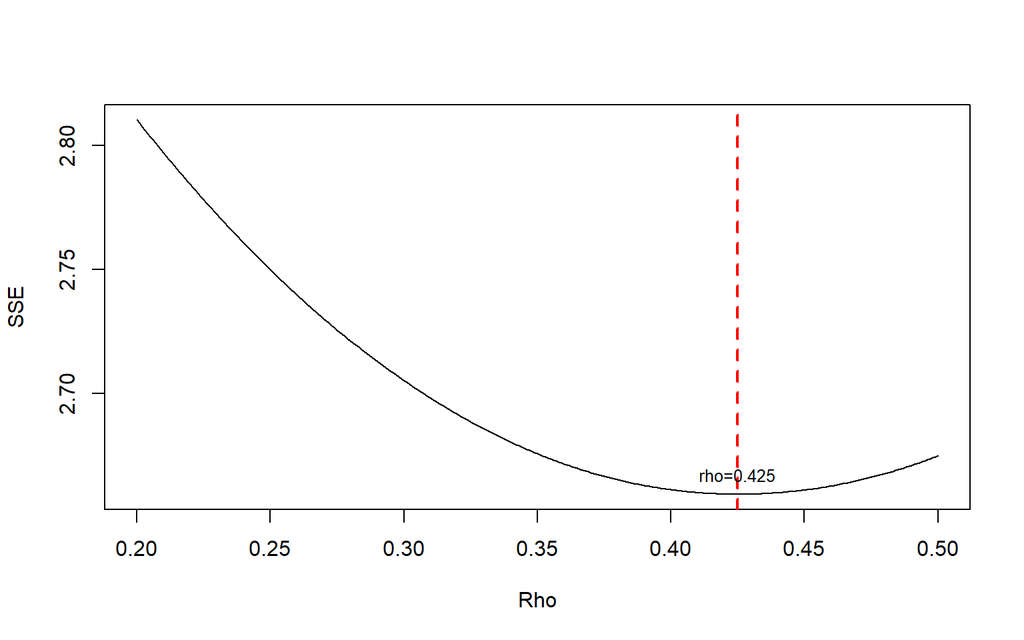

```r
rho_opt <- tabOpt$rho[which.min(tabOpt$SSE)]
sse_opt <- min(tabOpt$SSE)

#Grafik SSE optimum
plot(tabOpt$SSE ~ tabOpt$rho, type = "l", xlab = "Rho", ylab = "SSE")
abline(v = rho_opt, lty = 2, col = "red", lwd = 2)
text(x = rho_opt, y = sse_opt,
     labels = paste0("rho=", round(rho_opt, 3)),
     pos = 3, cex = 0.8)
```

Perhitungan yang dilakukan aplikasi `R` menunjukkan bahwa nilai $ρ$ optimum, yaitu saat SSE terkecil terdapat pada nilai $ρ=0.425$. Hal tersebut juga ditunjukkan pada plot. Selanjutnya, model dapat didapatkan dengan mengevaluasi nilai $ρ$ ke dalam fungsi `hildreth.lu.func`, serta dilanjutkan dengan pengujian autokorelasi dengan uji Durbin-Watson. Namun, setelah pengecekan tersebut tidak lupa koefisien regresi tersebut digunakan untuk transformasi balik.

```r
#Model terbaik
modelHL1 <- hildreth.lu.func(rho_opt, model1)
summary(modelHL1)
```

```
##
## Call:
## lm(formula = y ~ x)
##
## Residuals:
##      Min       1Q   Median       3Q      Max
## -0.55517 -0.25066 -0.05505  0.25010  0.83017
##
## Coefficients:
##             Estimate Std. Error t value Pr(>|t|)
## (Intercept)  15.3655     0.9387   16.37 7.68e-12 ***
## x           -24.0848     1.9380  -12.43 5.88e-10 ***
## ---
## Signif. codes:  0 '***' 0.001 '**' 0.01 '*' 0.05 '.' 0.1 ' ' 1
##
## Residual standard error: 0.3955 on 17 degrees of freedom
## Multiple R-squared:  0.9008, Adjusted R-squared:  0.895
## F-statistic: 154.4 on 1 and 17 DF,  p-value: 5.88e-10
```

```r
#Transformasi Balik
cat("y = ", coef(modelHL1)[1]/(1-0.425), "+", coef(modelHL1)[2],"x", sep = "")
```

```
## y = 26.72268+-24.08484x
```

```r
#Deteksi autokorelasi
dwtest(modelHL1)
```

```
##
##  Durbin-Watson test
##
## data:  modelHL1
## DW = 1.9577, p-value = 0.4148
## alternative hypothesis: true autocorrelation is greater than 0
```

Hasil uji Durbin-Watson juga menunjukkan bawah nilai DW sebesar $1.9577$ berada pada selang daerah tidak ada autokorelasi, yaitu pada rentang DU < DW < 4-DU atau $1.4107 < DW < 2.5893$. Hal tersebut juga didukung oleh *p-value* sebesar $0.4148$, di mana *p-value* > $\alpha$=5%. Artinya tak tolak $H_0$ atau belum cukup bukti menyatakan bahwa ada autokorelasi dalam data nilai Market Share dengan metode Hildreth-Lu pada taraf nyata 5%.

## Perbandingan

Terakhir, akan dibandingkan nilai SSE dari ketiga metode (metode awal, metode Cochrane-Orcutt, dan Hildreth-Lu).

```r
#Perbandingan
sseModelawal <- anova(model1)$`Sum Sq`[-1]
sseModelCO <- anova(modelCOmanual1)$`Sum Sq`[-1]
sseModelHL <- anova(modelHL1)$`Sum Sq`[-1]
mseModelawal <- sseModelawal/length(data1$Market_share)
mseModelCO <- sseModelCO/length(data1$Market_share)
mseModelHL <- sseModelHL/length(data1$Market_share)
akurasi <- matrix(c(sseModelawal,sseModelCO,sseModelHL,
                    mseModelawal,mseModelCO,mseModelHL),nrow=2,ncol=3,byrow = T)
colnames(akurasi) <- c("Model Awal", "Model Cochrane-Orcutt", "Model Hildreth-Lu")
row.names(akurasi) <- c("SSE","MSE")
akurasi
```

```
##     Model Awal Model Cochrane-Orcutt Model Hildreth-Lu
## SSE  3.3082574             2.6593681         2.6593683
## MSE  0.1654129             0.1329684         0.1329684
```

Berdasarkan hasil perbandingan, model awal memiliki nilai SSE sebesar 3.3082574. Setelah dilakukan penanganan autokorelasi, model Cochrane-Orcutt dan Hildreth-Lu menghasilkan nilai SSE yang lebih kecil, yaitu 2.659368. Penurunan nilai SSE dan MSE menunjukkan bahwa kedua metode penanganan autokorelasi menghasilkan model yang lebih baik dibandingkan model awal. Nilai SSE dan MSE yang sama pada metode Cochrane-Orcutt dan Hildreth-Lu menunjukkan bahwa kedua metode menghasilkan tingkat akurasi yang sama pada data tersebut.

# Analisis Data 2

## Eksplorasi Data 2

### Scatter Plot

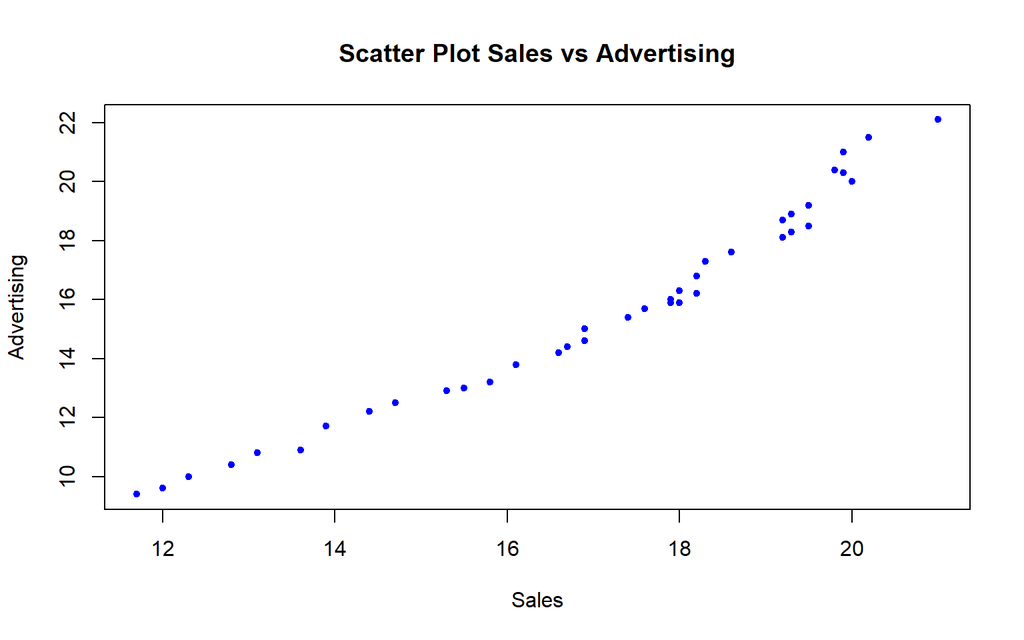

```r
plot(data2$Sales, data2$Advertising, pch = 20, col = "blue",
     main = "Scatter Plot Sales vs Advertising",
     xlab = "Sales",
     ylab = "Advertising")
```

```r
cor(data2$Sales, data2$Advertising)
```

```
## [1] 0.9795849
```

### Boxplot Sales

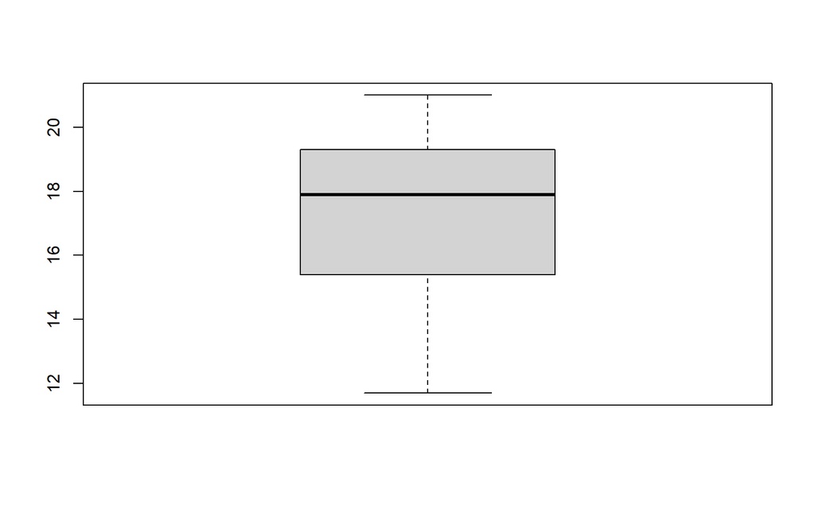

```r
boxplot(data2$Sales)
```

### Boxplot Advertising

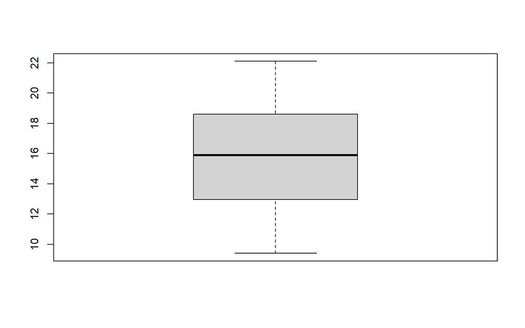

```r
boxplot(data2$Advertising)
```

## Pemodelan Regresi Linear

```r
model2 <- lm(Sales~Advertising, data2)
summary(model2)
```

```
##
## Call:
## lm(formula = Sales ~ Advertising, data = data2)
##
## Residuals:
##      Min       1Q   Median       3Q      Max
## -1.03758 -0.40343  0.08933  0.45674  0.74036
##
## Coefficients:
##             Estimate Std. Error t value Pr(>|t|)
## (Intercept)  5.96513    0.38092   15.66   <2e-16 ***
## Advertising  0.71035    0.02365   30.04   <2e-16 ***
## ---
## Signif. codes:  0 '***' 0.001 '**' 0.01 '*' 0.05 '.' 0.1 ' ' 1
##
## Residual standard error: 0.527 on 38 degrees of freedom
## Multiple R-squared:  0.9596, Adjusted R-squared:  0.9585
## F-statistic: 902.3 on 1 and 38 DF,  p-value: < 2.2e-16
```

## Pemenuhan Asumsi

### Linearitas

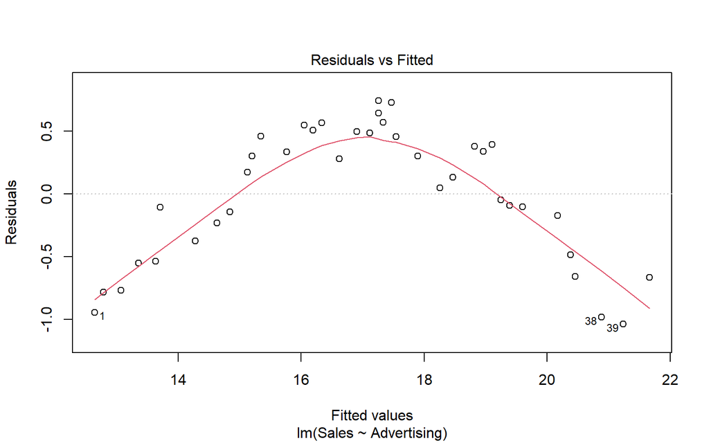

```r
plot(model2, which = 1)
```

### Normalitas

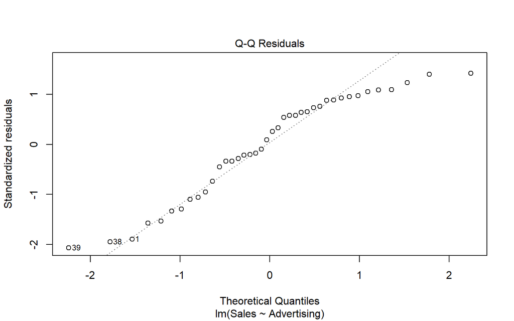

```r
plot(model2, which = 2)
```

```r
shapiro.test(residuals(model2))
```

```
##
##  Shapiro-Wilk normality test
##
## data:  residuals(model2)
## W = 0.93205, p-value = 0.0188
```

Uji Shapiro-Wilk menghasilkan nilai p-value sebesar 0.0188 < alpha 0.05. Oleh karena itu, cukup bukti untuk menolak H0, sehingga dapat disimpulkan bahwa sisaan tidak berdistribusi normal pada taraf nyata 5%.

### Homogenitas

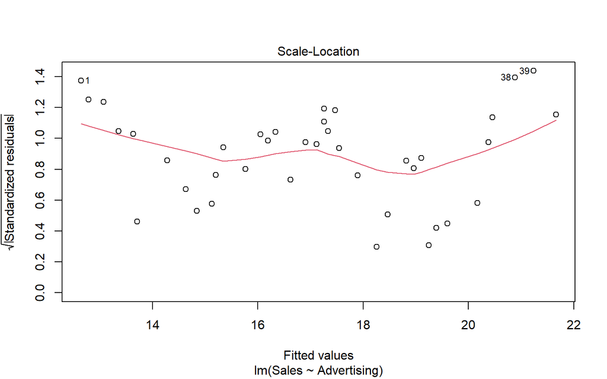

```r
plot(model2, which = 3)
```

```r
bptest(model2)
```

```
##
##  studentized Breusch-Pagan test
##
## data:  model2
## BP = 0.0037386, df = 1, p-value = 0.9512
```

Uji Breusch-Pagan menghasilkan nilai p-value sebesar 0.9512 > alpha 0.05. Oleh karena itu, tidak cukup bukti untuk menolak H0, sehingga dapat disimpulkan bahwa bahwa ragam sisaan homogen pada taraf nyata 5%.

### Sisaan Saling Bebas

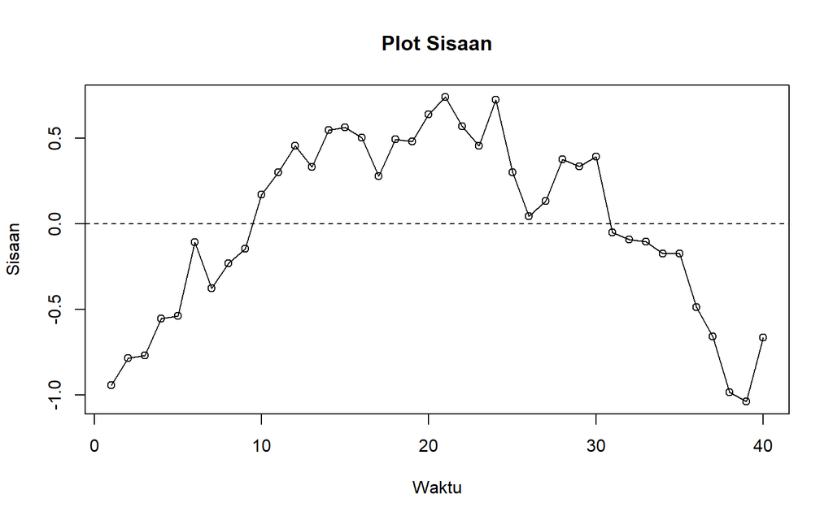

```r
plot(residuals(model2),
     type = "o",
     xlab = "Waktu",
     ylab = "Sisaan",
     main = "Plot Sisaan")
abline(h = 0, lty = 2)
```

```r
dwtest(model2)
```

```
##
##  Durbin-Watson test
##
## data:  model2
## DW = 0.16204, p-value < 2.2e-16
## alternative hypothesis: true autocorrelation is greater than 0
```

## Penanganan Autokorelasi dengan Cochrane-Orcutt

```r
modelCO2 <- cochrane.orcutt(model2)
modelCO2
```

```
## Cochrane-orcutt estimation for first order autocorrelation
##
## Call:
## lm(formula = Sales ~ Advertising, data = data2)
##
##  number of interaction: 39
##  rho 0.903123
##
## Durbin-Watson statistic
## (original):    0.16204 , p-value: 8.935e-20
## (transformed): 1.93925 , p-value: 3.78e-01
##
##  coefficients:
## (Intercept) Advertising
##   10.252375    0.488489
```

```r
rho2 <- modelCO2$rho
rho2
```

```
## [1] 0.9031233
```

```r
n2 <- nrow(data2)
Sales.trans2 <- data2$Sales[-1] - data2$Sales[-n2]*rho2
Advertising.trans2 <- data2$Advertising[-1] - data2$Advertising[-n2]*rho2

modelCOmanual2 <- lm(Sales.trans2~Advertising.trans2)
summary(modelCOmanual2)
```

```
##
## Call:
## lm(formula = Sales.trans2 ~ Advertising.trans2)
##
## Residuals:
##      Min       1Q   Median       3Q      Max
## -0.37730 -0.14957  0.01257  0.10464  0.45315
##
## Coefficients:
##                    Estimate Std. Error t value Pr(>|t|)
## (Intercept)         0.99322    0.14141   7.023 2.64e-08 ***
## Advertising.trans2  0.48849    0.07543   6.476 1.43e-07 ***
## ---
## Signif. codes:  0 '***' 0.001 '**' 0.01 '*' 0.05 '.' 0.1 ' ' 1
##
## Residual standard error: 0.1868 on 37 degrees of freedom
## Multiple R-squared:  0.5313, Adjusted R-squared:  0.5186
## F-statistic: 41.94 on 1 and 37 DF,  p-value: 1.426e-07
```

```r
#Mencari Penduga Koefisien Regresi setelah Transformasi ke Persamaan Awal
b0bintang2 <- modelCOmanual2$coefficients[1]
b02 <- b0bintang2/(1-rho2)
b12 <- modelCOmanual2$coefficients[2]
b02
```

```
## (Intercept)
##    10.25237
```

```r
b12
```

```
## Advertising.trans2
##          0.4884891
```

## Penanganan Autokorelasi dengan Metode Hildreth-Lu

```r
y2 <- data2$Sales
x2 <- data2$Advertising

# grid search rho 0-0.9
r2 <- seq(0, 0.9, by = 0.1)
tab2 <- data.frame(
  rho = r2,
  SSE = sapply(r2, function(rr) deviance(hildreth.lu(y2, x2, rr)))
)

tab2
```

```
##    rho      SSE
## 1  0.0 9.561851
## 2  0.1 7.845710
## 3  0.2 6.330287
## 4  0.3 5.015381
## 5  0.4 3.900668
## 6  0.5 2.985599
## 7  0.6 2.269173
## 8  0.7 1.749430
## 9  0.8 1.422573
## 10 0.9 1.291395
```

```r
rho_hat2 <- tab2$rho[which.min(tab2$SSE)]
fit_hl2 <- hildreth.lu(y2, x2, rho_hat2)
summary(fit_hl2)
```

```
##
## Call:
## lm(formula = y ~ x)
##
## Residuals:
##     Min      1Q  Median      3Q     Max
## -0.3749 -0.1461  0.0148  0.1057  0.4496
##
## Coefficients:
##             Estimate Std. Error t value Pr(>|t|)
## (Intercept)  1.01310    0.14198   7.135 1.87e-08 ***
## x            0.49358    0.07379   6.689 7.38e-08 ***
## ---
## Signif. codes:  0 '***' 0.001 '**' 0.01 '*' 0.05 '.' 0.1 ' ' 1
##
## Residual standard error: 0.1868 on 37 degrees of freedom
## Multiple R-squared:  0.5474, Adjusted R-squared:  0.5351
## F-statistic: 44.74 on 1 and 37 DF,  p-value: 7.382e-08
```

```r
hildreth.lu.func2 <- function(r, model2){
  x <- model.matrix(model2)[,-1]
  y <- model.response(model.frame(model2))
  n <- length(y)
  t <- 2:n
  y <- y[t]-r*y[t-1]
  x <- x[t]-r*x[t-1]

  return(lm(y~x))
}

#Rho optimal (pencarian lebih presisi di sekitar rho_hat2)
rOpt2 <- seq(max(0, rho_hat2-0.1), min(0.9, rho_hat2+0.1), by = 0.001)
tabOpt2 <- data.frame("rho" = rOpt2, "SSE" = sapply(rOpt2, function(i){deviance(hildreth.lu.func2(i, model2))}))
head(tabOpt2[order(tabOpt2$SSE),])
```

```
##       rho      SSE
## 101 0.900 1.291395
## 100 0.899 1.291519
## 99  0.898 1.291676
## 98  0.897 1.291865
## 97  0.896 1.292087
## 96  0.895 1.292339
```

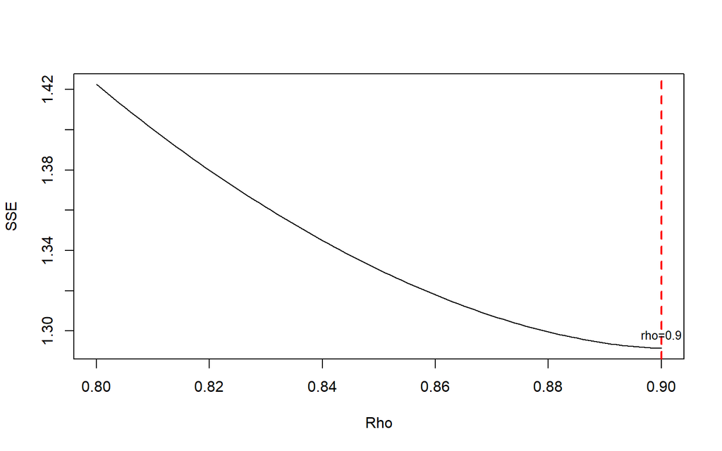

```r
rho_opt2 <- tabOpt2$rho[which.min(tabOpt2$SSE)]
sse_opt2 <- min(tabOpt2$SSE)

#Grafik SSE optimum
plot(tabOpt2$SSE ~ tabOpt2$rho, type = "l", xlab = "Rho", ylab = "SSE")
abline(v = rho_opt2, lty = 2, col = "red", lwd = 2)
text(x = rho_opt2, y = sse_opt2,
     labels = paste0("rho=", round(rho_opt2, 3)),
     pos = 3, cex = 0.8)
```

```r
modelHL2 <- hildreth.lu.func2(rho_opt2, model2)
summary(modelHL2)
```

```
##
## Call:
## lm(formula = y ~ x)
##
## Residuals:
##     Min      1Q  Median      3Q     Max
## -0.3749 -0.1461  0.0148  0.1057  0.4496
##
## Coefficients:
##             Estimate Std. Error t value Pr(>|t|)
## (Intercept)  1.01310    0.14198   7.135 1.87e-08 ***
## x            0.49358    0.07379   6.689 7.38e-08 ***
## ---
## Signif. codes:  0 '***' 0.001 '**' 0.01 '*' 0.05 '.' 0.1 ' ' 1
##
## Residual standard error: 0.1868 on 37 degrees of freedom
## Multiple R-squared:  0.5474, Adjusted R-squared:  0.5351
## F-statistic: 44.74 on 1 and 37 DF,  p-value: 7.382e-08
```

```r
#Transformasi Balik
cat("y = ", coef(modelHL2)[1]/(1-rho_opt2), "+", coef(modelHL2)[2],"x", sep = "")
```

```
## y = 10.13098+0.4935821x
```

Setelah dilakukan tranformasi balik, didapatkan model dengan metode Hildreth-Lu sebagai berikut.
$$y_i=10.13098+0.4935821x_t$$

```r
dwtest(modelHL2)
```

```
##
##  Durbin-Watson test
##
## data:  modelHL2
## DW = 1.9402, p-value = 0.3782
## alternative hypothesis: true autocorrelation is greater than 0
```

## Perbandingan (Data 2)

```r
sseModelawal2 <- anova(model2)$`Sum Sq`[-1]
sseModelCO2 <- anova(modelCOmanual2)$`Sum Sq`[-1]
sseModelHL2 <- anova(modelHL2)$`Sum Sq`[-1]
mseModelawal2 <- sseModelawal2/length(data2$Sales)
mseModelCO2 <- sseModelCO2/length(data2$Sales)
mseModelHL2 <- sseModelHL2/length(data2$Sales)
akurasi2 <- matrix(c(sseModelawal2,sseModelCO2,sseModelHL2,
                    mseModelawal2,mseModelCO2,mseModelHL2),nrow=2,ncol=3,byrow = T)
colnames(akurasi2) <- c("Model Awal", "Model Cochrane-Orcutt", "Model Hildreth-Lu")
row.names(akurasi2) <- c("SSE","MSE")
akurasi2
```

```
##     Model Awal Model Cochrane-Orcutt Model Hildreth-Lu
## SSE 10.5545322            1.29122545        1.29139494
## MSE  0.2638633            0.03228064        0.03228487
```

Berdasarkan hasil perbandingan, model awal memiliki nilai SSE sebesar 10.554. Setelah dilakukan penanganan autokorelasi, model Cochrane-Orcutt dan Hildreth-Lu menghasilkan nilai SSE yang lebih kecil, yaitu 1.291. Penurunan nilai SSE dan MSE menunjukkan bahwa kedua metode penanganan autokorelasi menghasilkan model yang lebih baik dibandingkan model awal. Nilai SSE dan MSE yang sama pada metode Cochrane-Orcutt dan Hildreth-Lu menunjukkan bahwa kedua metode menghasilkan tingkat akurasi yang sama pada data tersebut.